# Q & K Box 14.1

# Deriving components (modified from Jackson 2003)

There are two strategies for extracting eigenvectors (components) and their eigenvalues from a multivariate data set of n objects by p variables. First, we can use an eigenanalysis (spectral decomposition) of a p x p association matrix between variables. Second, we can use a singular value decomposition (SVD) of the n x p data matrix, with variables standardized as necessary.

Consider the matrix (Y) of raw data from Clevenger and Waltho (2000), who recorded the numbers of seven taxa of wildlife for eleven underpasses in Alberta, Canada.

Load the vegan package

```r
library(tidyverse)
library(vegan)
#datasets: clevenger.csv
clevenger <- read_csv("../data/clevenger.csv")
head(clevenger,10)
```

| underpass | width | height | length | openness | noise | egdist | forcov | draindist | raildist | towndist | hui | bike | horse | foot | bbear | gbear | cougar | wolf | deer | elk | moose |
| --- | --- | --- | --- | --- | --- | --- | --- | --- | --- | --- | --- | --- | --- | --- | --- | --- | --- | --- | --- | --- | --- |
| a | 9.8 | 2.8 | 63.0 | 0.43 | 68.1 | 0.0 | 22.3 | 1.0 | 0.50 | 1.6 | 0.4 | 0 | 6 | 7 | 10 | 0 | 5 | 1 | 554 | 825 | 1 |
| b | 13.4 | 2.5 | 83.2 | 0.40 | 70.5 | 2.1 | 63.3 | 0.0 | 0.75 | 3.5 | 1.9 | 5 | 3 | 45 | 20 | 0 | 29 | 7 | 42 | 201 | 0 |
| c | 4.2 | 3.5 | 96.1 | 0.15 | 64.1 | 3.5 | 11.9 | 0.1 | 0.80 | 5.5 | 1.8 | 6 | 6 | 14 | 43 | 0 | 3 | 3 | 294 | 331 | 1 |
| d | 9.8 | 2.9 | 40.0 | 0.71 | 66.8 | 5.8 | 15.2 | 0.4 | 0.02 | 6.0 | 0.6 | 21 | 5 | 20 | 37 | 2 | 30 | 28 | 253 | 1199 | 0 |
| e | 9.5 | 2.9 | 39.7 | 0.69 | 66.0 | 10.5 | 47.3 | 0.6 | 0.02 | 1.5 | 5.3 | 189 | 42 | 34 | 13 | 0 | 7 | 3 | 215 | 1062 | 0 |
| f | 14.9 | 3.2 | 38.0 | 1.25 | 63.8 | 11.5 | 16.1 | 0.0 | 0.02 | 0.5 | 5.3 | 8 | 138 | 77 | 8 | 0 | 0 | 5 | 21 | 467 | 0 |
| g | 10.0 | 3.0 | 27.1 | 1.10 | 64.3 | 12.0 | 35.9 | 0.6 | 0.25 | 0.2 | 15.2 | 462 | 186 | 129 | 0 | 0 | 4 | 1 | 61 | 1576 | 0 |
| h | 9.8 | 2.7 | 27.2 | 0.97 | 67.4 | 14.4 | 23.3 | 1.2 | 1.20 | 1.7 | 3.2 | 19 | 12 | 80 | 4 | 0 | 4 | 5 | 338 | 1522 | 0 |
| i | 10.3 | 2.8 | 25.6 | 1.12 | 67.4 | 17.0 | 27.5 | 0.4 | 0.40 | 5.2 | 11.4 | 595 | 58 | 241 | 8 | 0 | 20 | 77 | 288 | 821 | 0 |
| j | 9.0 | 2.9 | 40.1 | 0.65 | 67.1 | 18.8 | 23.9 | 0.2 | 0.75 | 7.2 | 0.6 | 1 | 10 | 10 | 34 | 5 | 15 | 146 | 291 | 683 | 0 |

### Illustrate centroid using relationship between human activity index (hui) and elk numbers

Plots used for QK use the ggplot classic theme, with some tweaks. Tweaks are consolidated into theme_QK; use this theme for figures and tweak the theme to avoid repetitive code changes.

```
## ℹ SHA-1 hash of file is "a6df54e0f71bb238af60abd3d8ca755800be0aeb"
```

Fig 14.2

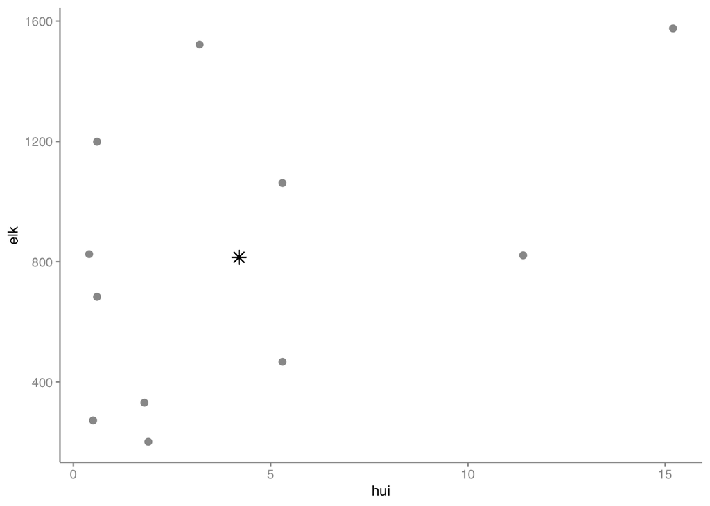

```r
f14_2<-ggplot(data=clevenger,aes(x=hui, y=elk))+
  geom_point(color=sc, size=ss, alpha= 1) +
  theme_qk()+
  geom_point(aes(x=mean(hui),y=mean(elk)), pch=8, size=3)
f14_2
```

### Get centered and standardized raw data matrices

```r
# centered
clevenger.cen <- scale(clevenger[,c('bbear','gbear','cougar','wolf','deer','elk','moose')], scale=F)
clevenger.cen
```

```
##            bbear      gbear     cougar        wolf        deer         elk
##  [1,]  -7.545455 -0.6363636  -5.636364 -27.2727273  334.818182   10.545455
##  [2,]   2.454545 -0.6363636  18.363636 -21.2727273 -177.181818 -613.454545
##  [3,]  25.454545 -0.6363636  -7.636364 -25.2727273   74.818182 -483.454545
##  [4,]  19.454545  1.3636364  19.363636  -0.2727273   33.818182  384.545455
##  [5,]  -4.545455 -0.6363636  -3.636364 -25.2727273   -4.181818  247.545455
##  [6,]  -9.545455 -0.6363636 -10.636364 -23.2727273 -198.181818 -347.454545
##  [7,] -17.545455 -0.6363636  -6.636364 -27.2727273 -158.181818  761.545455
##  [8,] -13.545455 -0.6363636  -6.636364 -23.2727273  118.818182  707.545455
##  [9,]  -9.545455 -0.6363636   9.363636  48.7272727   68.818182    6.545455
## [10,]  16.454545  4.3636364   4.363636 117.7272727   71.818182 -131.454545
## [11,]  -1.545455 -0.6363636 -10.636364   6.7272727 -165.181818 -542.454545
##            moose
##  [1,]  0.8181818
##  [2,] -0.1818182
##  [3,]  0.8181818
##  [4,] -0.1818182
##  [5,] -0.1818182
##  [6,] -0.1818182
##  [7,] -0.1818182
##  [8,] -0.1818182
##  [9,] -0.1818182
## [10,] -0.1818182
## [11,] -0.1818182
## attr(,"scaled:center")
##       bbear       gbear      cougar        wolf        deer         elk
##  17.5454545   0.6363636  10.6363636  28.2727273 219.1818182 814.4545455
##       moose
##   0.1818182
```

```r
# get standardized raw data
clevenger.stan <- scale(clevenger[,c('bbear','gbear','cougar','wolf','deer','elk','moose')], scale=T)
clevenger.stan
```

```
##            bbear      gbear     cougar         wolf        deer         elk
##  [1,] -0.5261348 -0.4061812 -0.5068669 -0.601179227  2.05348246  0.02183648
##  [2,]  0.1711523 -0.4061812  1.6514052 -0.468919797 -1.08667861 -1.27028099
##  [3,]  1.7749127 -0.4061812 -0.6867229 -0.557092751  0.45886942 -1.00108985
##  [4,]  1.3565404  0.8703883  1.7413332 -0.006011792  0.20741121  0.79627869
##  [5,] -0.3169487 -0.4061812 -0.3270109 -0.557092751 -0.02564762  0.51259264
##  [6,] -0.6655923 -0.4061812 -0.9565070 -0.513006274 -1.21547428 -0.71947450
##  [7,] -1.2234220 -0.4061812 -0.5967949 -0.601179227 -0.97014920  1.57693299
##  [8,] -0.9445071 -0.4061812 -0.5967949 -0.513006274  0.72872701  1.46511513
##  [9,] -0.6655923 -0.4061812  0.8420531  1.074106886  0.42207066  0.01355368
## [10,]  1.1473543  2.7852425  0.3924131  2.595090331  0.44047004 -0.27220307
## [11,] -0.1077626 -0.4061812 -0.9565070  0.148290876 -1.01308109 -1.12326121
##            moose
##  [1,]  2.0225996
##  [2,] -0.4494666
##  [3,]  2.0225996
##  [4,] -0.4494666
##  [5,] -0.4494666
##  [6,] -0.4494666
##  [7,] -0.4494666
##  [8,] -0.4494666
##  [9,] -0.4494666
## [10,] -0.4494666
## [11,] -0.4494666
## attr(,"scaled:center")
##       bbear       gbear      cougar        wolf        deer         elk
##  17.5454545   0.6363636  10.6363636  28.2727273 219.1818182 814.4545455
##       moose
##   0.1818182
## attr(,"scaled:scale")
##       bbear       gbear      cougar        wolf        deer         elk
##  14.3412945   1.5666989  11.1200065  45.3653853 163.0489609 482.9282273
##       moose
##   0.4045199
```

### Generate covariance and correlation matrices

Covariance matrix for wildlife

```r
clevenger.cov <- cov(clevenger[,c('bbear','gbear','cougar','wolf','deer','elk','moose')])
```

Correlation matrix for wildlife

```r
clevenger.cor <- cor(clevenger[,c('bbear','gbear','cougar','wolf','deer','elk','moose')])
```

### Derive eigenvectors and eigenvalues based on correlation matrix

```r
clevenger.eigen <- eigen(clevenger.cor)
clevenger.eigen
```

```
## eigen() decomposition
## $values
## [1] 2.48262264 1.79202546 1.33144952 0.81062441 0.42903804 0.08769838 0.06654156
##
## $vectors
##            [,1]        [,2]        [,3]         [,4]         [,5]        [,6]
## [1,] -0.4480426 -0.32853418  0.28726775 -0.195436794  0.586304172 -0.47611634
## [2,] -0.5734521  0.04251404 -0.20081526  0.255898326  0.277980195  0.61766855
## [3,] -0.3798802  0.16723268  0.02083960 -0.817320247 -0.324352619  0.19419176
## [4,] -0.5355751  0.11425393 -0.14514937  0.430423505 -0.377378599 -0.28984791
## [5,] -0.0895651 -0.53785185 -0.53718087 -0.082108683 -0.345693443 -0.27316305
## [6,]  0.1440767  0.19264407 -0.75205162 -0.190408179  0.460246579 -0.06783799
## [7,]  0.1023762 -0.72307729  0.03876746 -0.006827542 -0.004932548  0.43687126
##             [,7]
## [1,]  0.01286228
## [2,] -0.32364656
## [3,]  0.12791605
## [4,]  0.51705536
## [5,] -0.46180770
## [6,]  0.35194368
## [7,]  0.52368693
```

### Do PCA

```r
clevenger.pca <- princomp(~bbear+gbear+cougar+wolf+deer+elk+moose, cor=T, data=clevenger)
summary(clevenger.pca)
```

```
## Importance of components:
##                           Comp.1    Comp.2    Comp.3    Comp.4     Comp.5
## Standard deviation     1.5756340 1.3386656 1.1538845 0.9003468 0.65500995
## Proportion of Variance 0.3546604 0.2560036 0.1902071 0.1158035 0.06129115
## Cumulative Proportion  0.3546604 0.6106640 0.8008711 0.9166746 0.97796572
##                            Comp.6      Comp.7
## Standard deviation     0.29613912 0.257956501
## Proportion of Variance 0.01252834 0.009505937
## Cumulative Proportion  0.99049406 1.000000000
```

### Calculate dissimilarities for raw and standardized (by object and variables) and presence/absence

Calculate Euclidean, Chisq and Bray-Curtis measures

```r
# raw data
clev1 <- clevenger[c(16:22)]
vegdist(clev1, method="euclidean")
```

```
##             1          2          3          4          5          6          7
## 2   807.60944
## 3   559.22536  285.70264
## 4   482.24994 1020.42148  869.77008
## 5   413.65203  878.52092  735.87975  148.14520
## 6   642.10513  268.67452  307.02443  769.36467  625.89057
## 7   898.41638 1375.51699 1267.34723  426.34610  536.74389 1109.76439
## 8   729.73899 1354.08345 1192.45293  337.41962  476.25938 1101.61064  282.27115
## 9   277.08843  670.85095  497.11870  383.99870  262.83074  449.65431  792.24365
## 10  333.25666  560.41324  380.28016  530.91148  412.79050  374.65050  934.17129
## 11  746.34241   82.61961  250.68706  948.85405  806.90954  200.19491 1304.56621
##             8          9         10
## 2
## 3
## 4
## 5
## 6
## 7
## 8
## 9   706.65197
## 10  852.67637  156.65248
## 11 1282.26986  598.65265  487.83706
```

```r
vegdist(clev1, method="chisq")
```

```
##             1          2          3          4          5          6          7
## 2  1.21475615
## 3  0.47318577 1.17635422
## 4  0.61384857 0.86798529 0.78818807
## 5  0.58227734 1.05366620 0.83599435 0.21674323
## 6  0.89187108 1.12775158 1.09118378 0.39319617 0.31798393
## 7  0.91245764 1.17435640 1.16260729 0.45273730 0.34119097 0.14487655
## 8  0.55123078 1.11106385 0.84408915 0.27447668 0.07803388 0.35930254 0.36290581
## 9  0.55537285 0.99969109 0.77917948 0.37637843 0.45788835 0.64890817 0.69433371
## 10 0.87912364 1.14433514 0.93156102 0.73629009 0.86127129 0.96885842 1.04763957
## 11 0.86727424 1.09145007 0.91740896 0.53301980 0.63188889 0.64730790 0.75690369
##             8          9         10
## 2
## 3
## 4
## 5
## 6
## 7
## 8
## 9  0.45353095
## 10 0.86766247 0.46840925
## 11 0.65817925 0.43340441 0.42203679
```

```r
vegdist(clev1, method="bray")
```

```
##             1          2          3          4          5          6          7
## 2  0.69439528
## 3  0.38194109 0.44763860
## 4  0.25704584 0.67640693 0.43615108
## 5  0.21661721 0.66729206 0.42784810 0.08739909
## 6  0.47601476 0.41250000 0.38265306 0.51121951 0.44586341
## 7  0.41342989 0.74446162 0.65817868 0.20714510 0.23317471 0.54363042
## 8  0.28296115 0.76427256 0.50156986 0.14377557 0.18815002 0.58129739 0.09644381
## 9  0.13946360 0.63251818 0.32980413 0.18204850 0.16149562 0.41574344 0.37885154
## 10 0.22957198 0.61303462 0.28393726 0.25449871 0.25545675 0.40179104 0.46803977
## 11 0.61985336 0.21301775 0.34410646 0.61578401 0.59212880 0.30296128 0.67607727
##             8          9         10
## 2
## 3
## 4
## 5
## 6
## 7
## 8
## 9  0.27308066
## 10 0.35214966 0.10301508
## 11 0.70222222 0.53614079 0.51386202
```

```r
# standardized by object totals
clev1$total <- rowSums(clev1)
clev2 <- clev1
clev2$bbeart <- clev2$bbear/clev2$total
clev2$gbeart <- clev2$gbear/clev2$total
clev2$cougart <- clev2$cougar/clev2$total
clev2$wolft <- clev2$wolf/clev2$total
clev2$deert <- clev2$deer/clev2$total
clev2$elkt <- clev2$elk/clev2$total
clev2$mooset <- clev2$moose/clev2$total
clev3 <- clev2[c(9:15)]
vegdist(clev3, method="euclidean")
```

```
##             1          2          3          4          5          6          7
## 2  0.29179246
## 3  0.12178440 0.35929117
## 4  0.29812496 0.13708413 0.39569783
## 5  0.32348508 0.18337700 0.42722446 0.04981133
## 6  0.49248814 0.29906244 0.59366647 0.20059515 0.16923915
## 7  0.51524001 0.32757067 0.61901148 0.22713767 0.19227850 0.03372006
## 8  0.30979659 0.18687072 0.41558090 0.05280824 0.01784560 0.18366346 0.20546479
## 9  0.19197240 0.14525707 0.28422021 0.13185757 0.16974574 0.32684568 0.35299841
## 10 0.19530845 0.19611057 0.24342704 0.23556628 0.27826144 0.42261729 0.45121044
## 11 0.30182196 0.13136818 0.38360445 0.09734980 0.13739012 0.24941037 0.27993555
##             8          9         10
## 2
## 3
## 4
## 5
## 6
## 7
## 8
## 9  0.16038740
## 10 0.27108275 0.11528079
## 11 0.13945202 0.11532916 0.17839581
```

```r
vegdist(clev3, method="chisq")
```

```
##             1          2          3          4          5          6          7
## 2  1.04480761
## 3  0.39517291 1.04001877
## 4  0.60305175 0.70863697 0.76350072
## 5  0.58507556 0.86215541 0.80156474 0.18679083
## 6  0.89540748 0.94138220 1.07368158 0.37617696 0.31635064
## 7  0.91715806 0.98417343 1.13041746 0.42787726 0.33966677 0.12188311
## 8  0.55354775 0.90889652 0.79773472 0.23202001 0.06650063 0.35481352 0.36496751
## 9  0.52716675 0.82688142 0.71506346 0.35025941 0.42619090 0.62838501 0.67298864
## 10 0.81600325 0.98389894 0.86660229 0.68588704 0.80144200 0.92462096 0.99390701
## 11 0.82056558 0.90283478 0.88548124 0.47730196 0.56841064 0.60119998 0.69403213
##             8          9         10
## 2
## 3
## 4
## 5
## 6
## 7
## 8
## 9  0.41801288
## 10 0.80255881 0.43516350
## 11 0.58842686 0.38209782 0.40990737
```

```r
vegdist(clev3, method="bray")
```

```
##             1          2          3          4          5          6          7
## 2  0.25709624
## 3  0.10060384 0.29656881
## 4  0.23423329 0.12596108 0.31352318
## 5  0.23217985 0.16959866 0.32749288 0.04492874
## 6  0.35922996 0.25989493 0.44730095 0.15808796 0.12885306
## 7  0.36883090 0.28756431 0.46943475 0.18575734 0.14288204 0.03010544
## 8  0.22357908 0.18035023 0.32222974 0.05568031 0.01543636 0.14067860 0.14750545
## 9  0.16090572 0.14081535 0.25691866 0.11925162 0.14405652 0.26523724 0.28352834
## 10 0.15889643 0.21261103 0.22390939 0.19886655 0.23515136 0.35036401 0.37803340
## 11 0.25791006 0.12143928 0.31950879 0.09331596 0.12297082 0.21065032 0.24075576
##             8          9         10
## 2
## 3
## 4
## 5
## 6
## 7
## 8
## 9  0.13632334
## 10 0.23082839 0.09820268
## 11 0.13047339 0.11047068 0.15319319
```

```r
# standardized by variable totals
clev1$bbeart <- clev1$bbear/sum(clev2$bbear)
clev1$gbeart <- clev1$gbear/sum(clev2$gbear)
clev1$cougart <- clev1$cougar/sum(clev2$cougar)
clev1$wolft <- clev1$wolf/sum(clev2$wolf)
clev1$deert <- clev1$deer/sum(clev2$deer)
clev1$elkt <- clev1$elk/sum(clev2$elk)
clev1$mooset <- clev1$moose/sum(clev2$moose)
clev4 <- clev1[c(9:15)]
vegdist(clev4, method="euclidean")
```

```
##            1         2         3         4         5         6         7
## 2  0.5874372
## 3  0.2103305 0.5699869
## 4  0.6494049 0.3377750 0.6340280
## 5  0.5206197 0.2263239 0.5320355 0.3777360
## 6  0.5500617 0.2574895 0.5446442 0.4374485 0.1231964
## 7  0.5491779 0.2835227 0.5730657 0.4282729 0.1122824 0.1365675
## 8  0.5150571 0.2989734 0.5558359 0.4101989 0.0900685 0.1809769 0.1176054
## 9  0.5817512 0.2750346 0.6030030 0.3719280 0.2669713 0.3108749 0.3100064
## 10 1.0062311 0.8620352 0.9929078 0.5898117 0.8607697 0.8737626 0.8868434
## 11 0.5581777 0.2646868 0.5392290 0.4210031 0.1632272 0.1080943 0.2029463
##            8         9        10
## 2
## 3
## 4
## 5
## 6
## 7
## 8
## 9  0.2815680
## 10 0.8705775 0.7613418
## 11 0.2183625 0.2497030 0.8212754
```

```r
vegdist(clev4, method="chisq")
```

```
##            1         2         3         4         5         6         7
## 2  2.1918656
## 3  0.6060261 2.1062286
## 4  1.7774812 1.2249504 1.7410878
## 5  1.6550584 1.4861911 1.7333325 1.0365979
## 6  1.9594176 1.9177901 1.8499636 1.3528694 0.8747182
## 7  2.2679736 2.2799015 2.4479938 1.8581292 1.2332715 1.3157014
## 8  1.7397774 1.9752053 1.9751799 1.4191550 0.5881129 1.1561780 1.0587556
## 9  1.8312148 1.3956048 1.9103379 1.1027533 1.1541210 1.4626882 1.8867908
## 10 2.0304452 1.9180098 2.0047472 0.8446477 1.6407999 1.7194328 2.2843090
## 11 2.0549749 1.9295504 1.8915082 1.4251156 1.4681142 1.1908051 2.2198998
##            8         9        10
## 2
## 3
## 4
## 5
## 6
## 7
## 8
## 9  1.3639082
## 10 1.8454187 1.2995151
## 11 1.7491817 1.0384181 1.3874031
```

```r
vegdist(clev4, method="bray")
```

```
##            1         2         3         4         5         6         7
## 2  0.7935939
## 3  0.1946466 0.7313399
## 4  0.7025767 0.4394077 0.6273209
## 5  0.5585673 0.5340500 0.6373176 0.5103013
## 6  0.7967183 0.6667775 0.8130980 0.7995520 0.5163939
## 7  0.7327162 0.7631796 0.8423259 0.6979275 0.3784111 0.6411470
## 8  0.5534611 0.7211135 0.6688852 0.5708830 0.2495338 0.6089989 0.2493285
## 9  0.6247022 0.4935050 0.7063851 0.4243562 0.4254924 0.7001292 0.6606665
## 10 0.7737168 0.7196663 0.7162999 0.3730783 0.7021629 0.8687325 0.8555458
## 11 0.8154067 0.5611676 0.7505849 0.6556519 0.5621685 0.4729512 0.7700434
##            8         9        10
## 2
## 3
## 4
## 5
## 6
## 7
## 8
## 9  0.4637913
## 10 0.7406492 0.4797086
## 11 0.7153495 0.5501897 0.7432297
```

**create pres/abs datafile**

```r
clev5 <- clevenger[c(16:22)]
clev5[clev5>0] <-1
clev5
```

| bbear | gbear | cougar | wolf | deer | elk | moose |
| --- | --- | --- | --- | --- | --- | --- |
| 1 | 0 | 1 | 1 | 1 | 1 | 1 |
| 1 | 0 | 1 | 1 | 1 | 1 | 0 |
| 1 | 0 | 1 | 1 | 1 | 1 | 1 |
| 1 | 1 | 1 | 1 | 1 | 1 | 0 |
| 1 | 0 | 1 | 1 | 1 | 1 | 0 |
| 1 | 0 | 0 | 1 | 1 | 1 | 0 |
| 0 | 0 | 1 | 1 | 1 | 1 | 0 |
| 1 | 0 | 1 | 1 | 1 | 1 | 0 |
| 1 | 0 | 1 | 1 | 1 | 1 | 0 |
| 1 | 1 | 1 | 1 | 1 | 1 | 0 |

[output cut: 1 more lines]

```r
vegdist(clev5, method="jaccard")
```

```
##            1         2         3         4         5         6         7
## 2  0.1666667
## 3  0.0000000 0.1666667
## 4  0.2857143 0.1666667 0.2857143
## 5  0.1666667 0.0000000 0.1666667 0.1666667
## 6  0.3333333 0.2000000 0.3333333 0.3333333 0.2000000
## 7  0.3333333 0.2000000 0.3333333 0.3333333 0.2000000 0.4000000
## 8  0.1666667 0.0000000 0.1666667 0.1666667 0.0000000 0.2000000 0.2000000
## 9  0.1666667 0.0000000 0.1666667 0.1666667 0.0000000 0.2000000 0.2000000
## 10 0.2857143 0.1666667 0.2857143 0.0000000 0.1666667 0.3333333 0.3333333
## 11 0.3333333 0.2000000 0.3333333 0.3333333 0.2000000 0.0000000 0.4000000
##            8         9        10
## 2
## 3
## 4
## 5
## 6
## 7
## 8
## 9  0.0000000
## 10 0.1666667 0.1666667
## 11 0.2000000 0.2000000 0.3333333
```

```r
vegdist(clev5, method="bray")
```

```
##             1          2          3          4          5          6          7
## 2  0.09090909
## 3  0.00000000 0.09090909
## 4  0.16666667 0.09090909 0.16666667
## 5  0.09090909 0.00000000 0.09090909 0.09090909
## 6  0.20000000 0.11111111 0.20000000 0.20000000 0.11111111
## 7  0.20000000 0.11111111 0.20000000 0.20000000 0.11111111 0.25000000
## 8  0.09090909 0.00000000 0.09090909 0.09090909 0.00000000 0.11111111 0.11111111
## 9  0.09090909 0.00000000 0.09090909 0.09090909 0.00000000 0.11111111 0.11111111
## 10 0.16666667 0.09090909 0.16666667 0.00000000 0.09090909 0.20000000 0.20000000
## 11 0.20000000 0.11111111 0.20000000 0.20000000 0.11111111 0.00000000 0.25000000
##             8          9         10
## 2
## 3
## 4
## 5
## 6
## 7
## 8
## 9  0.00000000
## 10 0.09090909 0.09090909
## 11 0.11111111 0.11111111 0.20000000
```

```r
# Problem with code; needs to be fixed
#mahalanobis(clev1, colMeans(clev1), cov(clev1))
```

### Fig 14.3 - ordination with BC MDS

```r
clev6 <- clevenger[c(1,16:22)]
clev6.stand <- decostand(clev6[,2:8], "total")
clev6.stand.bc <- vegdist(clev6.stand,"bray")
clev6.mds <- metaMDS(clev6.stand.bc,k=2)
```

```
## *** Best solution repeated 10 times
```

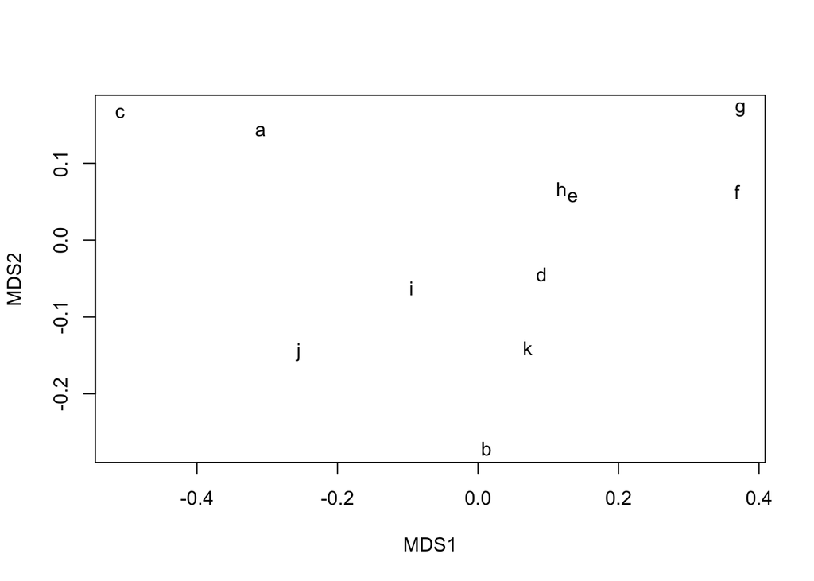

```r
plot(clev6.mds$points,type="n", )
text(clev6.mds$points,lab=clev6$underpass, col="black")
```

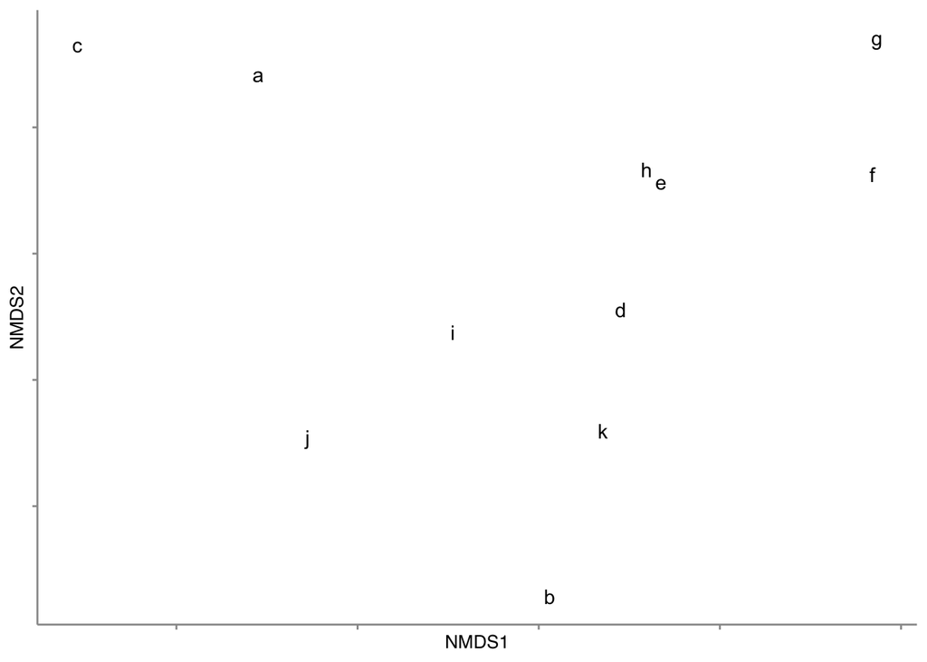

```r
mdsplot <- as.data.frame(scores(clev6.mds))
mdsplot$underpass<-clev6$underpass
f14_3<-ggplot(data=mdsplot,aes(x=NMDS1, y=NMDS2, label=underpass))+
  geom_text()+
  theme_qk()+
  theme(axis.text = element_blank())
f14_3
```